# WeRateDogs_data_analysis

My goal: wrangle WeRateDogs Twitter data to create interesting and trustworthy analyses and visualizations. The Twitter archive is great, but it only contains very basic tweet information. Additional gathering, then assessing and cleaning is required for "Wow!"-worthy analyses and visualizations.

key points:

### Dirty Data:

- Data which has issues with its content is often called low quality data and can include things like inaccurate data, corrupted data and duplicate data.

### Messy Data:

- Data which has issues with its structure. It is often referred to as untidy. Tidy data means each variable forms a column, each observation forms a row and each type of observational unit forms a table. Any other arrangement is messy.

### There are three steps

- Gathering the Data
- Assessing the Data
- Cleaning the data
- Finally,Visualizing and analysing the data we get after the completion of the first three steps

## Gather

```python
#importing the necessary packages
import pandas as pd
import numpy as np
import requests
import json
import tweepy
import os
import seaborn as sns
import matplotlib.pyplot as plt
%matplotlib inline
```

## Dataset_1 is directly downloaded from given link in the instructions

```python
#Dataset_1 is directly downloaded from given link in the instructions
twitter_archieve=pd.read_csv('twitter-archive-enhanced.csv')
twitter_archieve.head()
```

|  | tweet_id | in_reply_to_status_id | in_reply_to_user_id | timestamp | source | text | retweeted_status_id | retweeted_status_user_id | retweeted_status_timestamp | expanded_urls | rating_numerator | rating_denominator | name | doggo | floofer | pupper | puppo |
| --- | --- | --- | --- | --- | --- | --- | --- | --- | --- | --- | --- | --- | --- | --- | --- | --- | --- |
| 0 | 892420643555336193 | NaN | NaN | 2017-08-01 16:23:56 +0000 | <a href="http://twitter.com/download/iphone" r... | This is Phineas. He's a mystical boy. Only eve... | NaN | NaN | NaN | https://twitter.com/dog_rates/status/892420643... | 13 | 10 | Phineas | None | None | None | None |
| 1 | 892177421306343426 | NaN | NaN | 2017-08-01 00:17:27 +0000 | <a href="http://twitter.com/download/iphone" r... | This is Tilly. She's just checking pup on you.... | NaN | NaN | NaN | https://twitter.com/dog_rates/status/892177421... | 13 | 10 | Tilly | None | None | None | None |
| 2 | 891815181378084864 | NaN | NaN | 2017-07-31 00:18:03 +0000 | <a href="http://twitter.com/download/iphone" r... | This is Archie. He is a rare Norwegian Pouncin... | NaN | NaN | NaN | https://twitter.com/dog_rates/status/891815181... | 12 | 10 | Archie | None | None | None | None |
| 3 | 891689557279858688 | NaN | NaN | 2017-07-30 15:58:51 +0000 | <a href="http://twitter.com/download/iphone" r... | This is Darla. She commenced a snooze mid meal... | NaN | NaN | NaN | https://twitter.com/dog_rates/status/891689557... | 13 | 10 | Darla | None | None | None | None |
| 4 | 891327558926688256 | NaN | NaN | 2017-07-29 16:00:24 +0000 | <a href="http://twitter.com/download/iphone" r... | This is Franklin. He would like you to stop ca... | NaN | NaN | NaN | https://twitter.com/dog_rates/status/891327558... | 12 | 10 | Franklin | None | None | None | None |

```python
#create a folder
folder_name="file2"
if not os.path.exists(folder_name):
    os.makedirs(folder_name)
```

## Dataset-2 is downloaded using request from the udacity server

```python
#Dataset-2 is downloaded using request from the udacity server
url='https://d17h27t6h515a5.cloudfront.net/topher/2017/August/599fd2ad_image-predictions/image-predictions.tsv'
results=requests.get(url)
with open(os.path.join(folder_name,url.split('/')[-1]),mode='wb') as file:
       file.write(results.content)
```

```python
#seeing and extracting the first file using os.listdir
k=os.listdir(folder_name)
print(k[0])
image_predict=pd.read_csv(k[0],sep="\t")
image_predict.head()
```

```
image-predictions.tsv
```

|  | tweet_id | jpg_url | img_num | p1 | p1_conf | p1_dog | p2 | p2_conf | p2_dog | p3 | p3_conf | p3_dog |
| --- | --- | --- | --- | --- | --- | --- | --- | --- | --- | --- | --- | --- |
| 0 | 666020888022790149 | https://pbs.twimg.com/media/CT4udn0WwAA0aMy.jpg | 1 | Welsh_springer_spaniel | 0.465074 | True | collie | 0.156665 | True | Shetland_sheepdog | 0.061428 | True |
| 1 | 666029285002620928 | https://pbs.twimg.com/media/CT42GRgUYAA5iDo.jpg | 1 | redbone | 0.506826 | True | miniature_pinscher | 0.074192 | True | Rhodesian_ridgeback | 0.072010 | True |
| 2 | 666033412701032449 | https://pbs.twimg.com/media/CT4521TWwAEvMyu.jpg | 1 | German_shepherd | 0.596461 | True | malinois | 0.138584 | True | bloodhound | 0.116197 | True |
| 3 | 666044226329800704 | https://pbs.twimg.com/media/CT5Dr8HUEAA-lEu.jpg | 1 | Rhodesian_ridgeback | 0.408143 | True | redbone | 0.360687 | True | miniature_pinscher | 0.222752 | True |
| 4 | 666049248165822465 | https://pbs.twimg.com/media/CT5IQmsXIAAKY4A.jpg | 1 | miniature_pinscher | 0.560311 | True | Rottweiler | 0.243682 | True | Doberman | 0.154629 | True |

## Dataset-3 using twitterapi

```python
#dataset-3 using twitterapi

auth = tweepy.OAuthHandler(consumer_key, consumer_secret)
auth.set_access_token(access_token, access_secret)

api = tweepy.API(auth,parser=tweepy.parsers.JSONParser())
```

```python
#collecting the twitter ids
twit_list=twitter_archieve['tweet_id'].to_list()
twit_list[:5]
```

```
[892420643555336193,
 892177421306343426,
 891815181378084864,
 891689557279858688,
 891327558926688256]
```

```python
len(twit_list)
```

```
2356
```

```python
#id=892420643555336193
#twit_list.index(id)
```

```python
data=[]
ids=[]
for id in twit_list:
    try:
        inform=api.get_status(id,tweet_mode='extended',wait_on_rate_limit=True,wait_on_rate_limit_notify=True)
        #print(id)
        #print(inform)
        ids.append(id)
        data.append(inform)
    except:
        print("hi",id,twit_list.index(id))
```

```
hi 888202515573088257 19
hi 873697596434513921 95
hi 872668790621863937 101
hi 872261713294495745 104
hi 869988702071779329 118
hi 866816280283807744 132
hi 861769973181624320 155
hi 856602993587888130 182
hi 851953902622658560 211
hi 845459076796616705 247
hi 844704788403113984 253
hi 842892208864923648 260
hi 837366284874571778 296
hi 837012587749474308 298
hi 829374341691346946 363
hi 827228250799742977 382
hi 812747805718642688 506
hi 802247111496568832 566
hi 779123168116150273 750
hi 775096608509886464 784
hi 771004394259247104 815
hi 770743923962707968 818
hi 759566828574212096 890
```

```
Rate limit reached. Sleeping for: 161
```

```
hi 754011816964026368 932
hi 680055455951884288 1726
```

```
Rate limit reached. Sleeping for: 268
```

```python
#store data in tweet_data.txt
with open('tweet_json.txt',mode='w') as file:
    json.dump(data,file)
```

```python
twitter_counts=pd.read_json('tweet_json.txt')
twitter_counts['tweet_id']=ids
```

```python
df_list=[]
for i in range(0,len(ids)):
    df_list.append({'favorite_count': data[i]['favorite_count'],
                        'retweet_count':data[i]['retweet_count']
                   })
```

```python
k=pd.DataFrame(df_list,columns=['favorite_count','retweet_count'])
k['ids']=ids
```

```python
twitter_counts=k[['ids','favorite_count','retweet_count']]
```

```python
twitter_counts.head(5)
```

|  | ids | favorite_count | retweet_count |
| --- | --- | --- | --- |
| 0 | 892420643555336193 | 36240 | 7715 |
| 1 | 892177421306343426 | 31252 | 5701 |
| 2 | 891815181378084864 | 23531 | 3780 |
| 3 | 891689557279858688 | 39525 | 7869 |
| 4 | 891327558926688256 | 37735 | 8486 |

```python
#instead of running the cell again and again converting into .csv file and would use by reading the .csv file
twitter_counts.to_csv('twitter_countsfin.csv')
```

```python
#reading the .csv file from local machine
twitter_counts3=pd.read_csv('twitter_countsfin.csv')
twitter_counts3.drop(columns='Unnamed: 0',inplace=True)
twitter_counts3.head()
```

|  | ids | favorite_count | retweet_count |
| --- | --- | --- | --- |
| 0 | 892420643555336193 | 36240 | 7715 |
| 1 | 892177421306343426 | 31252 | 5701 |
| 2 | 891815181378084864 | 23531 | 3780 |
| 3 | 891689557279858688 | 39525 | 7869 |
| 4 | 891327558926688256 | 37735 | 8486 |

```python
twitter_counts3.rename(columns={'ids':'tweet_id'},inplace=True)
twitter_counts3.head(3)
```

|  | tweet_id | favorite_count | retweet_count |
| --- | --- | --- | --- |
| 0 | 892420643555336193 | 36240 | 7715 |
| 1 | 892177421306343426 | 31252 | 5701 |
| 2 | 891815181378084864 | 23531 | 3780 |

## Assess

There are two types of issues:

- quality issues
- tidiness issues

Quality issues are mainly of four types: In the decreasing of their severity

- completeness-deals the missing data
- validity-deals the invalid data i.e invalid datatypes etc
- accuracy-deals with the data which is technically true but unlikely
- consistency-deals with the data with multiple representations

Tidiness issues dont follow the below conditions:

- each variable belongs to a column
- each observation belongs to a row
- each observational unit forms a table

### They are listed below:

#### Quality issues:

1.twitter-archive-enhanced.csv

- ID fields: The ID fields, like tweet_id, in_reply_to_status_id etc. should be objects, not integers or floats because they are not numeric and aren't intended to perform calculations
- remove the columns which are having more than 90% of null values as they arent required
- convert the datatype of timestamp :to_datetime
- From the anchor tag extract only what is the actual source for the source attribute
- convert the rating_numerator and rating_denominator columns to float. Then iterate through the dataset (text) and find the records having decimal rating in numerator. store the indices and the decimal rating and relocate these values with faulty values.
- Name attribute has irrelevant values so replace them with None

2.image-predictions.tsv

- In p1_conf we find 100% confidence in prediction might be technically true but its not possible in general so remove it
- p1, p2 and p3 columns have multiword dog breeds with (- or _ ) instead of white spaces
- p1, p2 and p3 columns have breeds some times with lowercase and other times with sentence case using capitalize() into required
- Create a new dog_breed column to store the breed of dog

3.from 'tweet_json.txt' in dataframe twitter_counts3(twitter_id,favorite_count,retweet_count)

- tweet_id is an integer convert into object

#### Tidiness issues:

1.twitter-archive-enhanced.csv

- For the various stages of dog:doggo,floofer,pupper,puppo create a column named 'dog_stages' for the multiple dog_stages.

*2)All the three dataframes belong to the same observational unit. so merge into one.*

```python
#writing it as df1
df1=twitter_archieve
df1.sample(5)
```

|  | tweet_id | in_reply_to_status_id | in_reply_to_user_id | timestamp | source | text | retweeted_status_id | retweeted_status_user_id | retweeted_status_timestamp | expanded_urls | rating_numerator | rating_denominator | name | doggo | floofer | pupper | puppo |
| --- | --- | --- | --- | --- | --- | --- | --- | --- | --- | --- | --- | --- | --- | --- | --- | --- | --- |
| 2266 | 667530908589760512 | NaN | NaN | 2015-11-20 02:32:25 +0000 | <a href="http://twitter.com" rel="nofollow">Tw... | Meet Naphaniel. He doesn't necessarily enjoy h... | NaN | NaN | NaN | https://twitter.com/dog_rates/status/667530908... | 10 | 10 | Naphaniel | None | None | None | None |
| 1773 | 678255464182861824 | NaN | NaN | 2015-12-19 16:47:58 +0000 | <a href="http://twitter.com/download/iphone" r... | This is Jessifer. She is a Bismoth Teriyaki. F... | NaN | NaN | NaN | https://twitter.com/dog_rates/status/678255464... | 9 | 10 | Jessifer | None | None | None | None |
| 825 | 769695466921623552 | NaN | NaN | 2016-08-28 00:37:54 +0000 | <a href="http://twitter.com/download/iphone" r... | This is Titan. He's trying to make friends. Of... | NaN | NaN | NaN | https://twitter.com/dog_rates/status/769695466... | 13 | 10 | Titan | None | None | None | None |
| 1461 | 694925794720792577 | NaN | NaN | 2016-02-03 16:49:55 +0000 | <a href="http://vine.co" rel="nofollow">Vine -... | Please only send in dogs. This t-rex is very s... | NaN | NaN | NaN | https://vine.co/v/iJvUqWQ166L | 5 | 10 | None | None | None | None | None |
| 847 | 766078092750233600 | NaN | NaN | 2016-08-18 01:03:45 +0000 | <a href="http://twitter.com/download/iphone" r... | RT @dog_rates: This is Colby. He's currently r... | 7.258423e+17 | 4.196984e+09 | 2016-04-29 00:21:01 +0000 | https://twitter.com/dog_rates/status/725842289... | 12 | 10 | Colby | None | None | None | None |

```python
#lets examine the null values
list_val1=df1.isnull().sum().tolist()
df1.isnull().sum()
```

```
tweet_id                         0
in_reply_to_status_id         2278
in_reply_to_user_id           2278
timestamp                        0
source                           0
text                             0
retweeted_status_id           2175
retweeted_status_user_id      2175
retweeted_status_timestamp    2175
expanded_urls                   59
rating_numerator                 0
rating_denominator               0
name                             0
doggo                            0
floofer                          0
pupper                           0
puppo                            0
dtype: int64
```

```python
list_val1
```

```
[0, 2278, 2278, 0, 0, 0, 2175, 2175, 2175, 59, 0, 0, 0, 0, 0, 0, 0]
```

```python
h=df1.shape[0]
print(h)
per_null_df1=[ (i/h)*100 for i in list_val1 ]
print(per_null_df1)
```

```
2356
[0.0, 96.68930390492359, 96.68930390492359, 0.0, 0.0, 0.0, 92.31748726655347, 92.31748726655347, 92.31748726655347, 2.504244482173175, 0.0, 0.0, 0.0, 0.0, 0.0, 0.0, 0.0]
```

```python
#writing as df2
df2=image_predict
df2.head()
```

|  | tweet_id | jpg_url | img_num | p1 | p1_conf | p1_dog | p2 | p2_conf | p2_dog | p3 | p3_conf | p3_dog |
| --- | --- | --- | --- | --- | --- | --- | --- | --- | --- | --- | --- | --- |
| 0 | 666020888022790149 | https://pbs.twimg.com/media/CT4udn0WwAA0aMy.jpg | 1 | Welsh_springer_spaniel | 0.465074 | True | collie | 0.156665 | True | Shetland_sheepdog | 0.061428 | True |
| 1 | 666029285002620928 | https://pbs.twimg.com/media/CT42GRgUYAA5iDo.jpg | 1 | redbone | 0.506826 | True | miniature_pinscher | 0.074192 | True | Rhodesian_ridgeback | 0.072010 | True |
| 2 | 666033412701032449 | https://pbs.twimg.com/media/CT4521TWwAEvMyu.jpg | 1 | German_shepherd | 0.596461 | True | malinois | 0.138584 | True | bloodhound | 0.116197 | True |
| 3 | 666044226329800704 | https://pbs.twimg.com/media/CT5Dr8HUEAA-lEu.jpg | 1 | Rhodesian_ridgeback | 0.408143 | True | redbone | 0.360687 | True | miniature_pinscher | 0.222752 | True |
| 4 | 666049248165822465 | https://pbs.twimg.com/media/CT5IQmsXIAAKY4A.jpg | 1 | miniature_pinscher | 0.560311 | True | Rottweiler | 0.243682 | True | Doberman | 0.154629 | True |

```python
#find the null values
df2.isnull().sum()
```

```
tweet_id    0
jpg_url     0
img_num     0
p1          0
p1_conf     0
p1_dog      0
p2          0
p2_conf     0
p2_dog      0
p3          0
p3_conf     0
p3_dog      0
dtype: int64
```

```python
#writing as twitter_counts3 in df3
df3=twitter_counts3
df3.head()
```

|  | tweet_id | favorite_count | retweet_count |
| --- | --- | --- | --- |
| 0 | 892420643555336193 | 36240 | 7715 |
| 1 | 892177421306343426 | 31252 | 5701 |
| 2 | 891815181378084864 | 23531 | 3780 |
| 3 | 891689557279858688 | 39525 | 7869 |
| 4 | 891327558926688256 | 37735 | 8486 |

```python
#null values
df3.isnull().sum()
```

```
tweet_id          0
favorite_count    0
retweet_count     0
dtype: int64
```

```python
#Now Finding the datatypes
df1.info()
```

```
<class 'pandas.core.frame.DataFrame'>
RangeIndex: 2356 entries, 0 to 2355
Data columns (total 17 columns):
tweet_id                      2356 non-null int64
in_reply_to_status_id         78 non-null float64
in_reply_to_user_id           78 non-null float64
timestamp                     2356 non-null object
source                        2356 non-null object
text                          2356 non-null object
retweeted_status_id           181 non-null float64
retweeted_status_user_id      181 non-null float64
retweeted_status_timestamp    181 non-null object
expanded_urls                 2297 non-null object
rating_numerator              2356 non-null int64
rating_denominator            2356 non-null int64
name                          2356 non-null object
doggo                         2356 non-null object
floofer                       2356 non-null object
pupper                        2356 non-null object
puppo                         2356 non-null object
dtypes: float64(4), int64(3), object(10)
memory usage: 313.0+ KB
```

```python
df2.info()
```

```
<class 'pandas.core.frame.DataFrame'>
RangeIndex: 2075 entries, 0 to 2074
Data columns (total 12 columns):
tweet_id    2075 non-null int64
jpg_url     2075 non-null object
img_num     2075 non-null int64
p1          2075 non-null object
p1_conf     2075 non-null float64
p1_dog      2075 non-null bool
p2          2075 non-null object
p2_conf     2075 non-null float64
p2_dog      2075 non-null bool
p3          2075 non-null object
p3_conf     2075 non-null float64
p3_dog      2075 non-null bool
dtypes: bool(3), float64(3), int64(2), object(4)
memory usage: 152.1+ KB
```

```python
df3.info()
```

```
<class 'pandas.core.frame.DataFrame'>
RangeIndex: 2331 entries, 0 to 2330
Data columns (total 3 columns):
tweet_id          2331 non-null int64
favorite_count    2331 non-null int64
retweet_count     2331 non-null int64
dtypes: int64(3)
memory usage: 54.8 KB
```

```python
#denominator values arent as per specified
df1.rating_denominator.value_counts()
```

```
10     2333
11        3
50        3
80        2
20        2
2         1
16        1
40        1
70        1
15        1
90        1
110       1
120       1
130       1
150       1
170       1
7         1
0         1
Name: rating_denominator, dtype: int64
```

```python
#numerator values arent as per specified
df1.rating_numerator.value_counts()
```

```
12      558
11      464
10      461
13      351
9       158
8       102
7        55
14       54
5        37
6        32
3        19
4        17
1         9
2         9
420       2
```

[output cut: 26 more lines]

```python
#Name attribute has None values and a typo error named 'a' value so its better to remove them
df1['name'].value_counts()
```

```
None         745
a             55
Charlie       12
Cooper        11
Lucy          11
            ...
Clybe          1
Kathmandu      1
Philippe       1
Shooter        1
Rontu          1
Name: name, Length: 957, dtype: int64
```

```python
k=df1[df1['name']=='a']['expanded_urls'].index
print(k)
```

```
Int64Index([  56,  649,  801, 1002, 1004, 1017, 1049, 1193, 1207, 1340, 1351,
            1361, 1368, 1382, 1499, 1737, 1785, 1853, 1854, 1877, 1878, 1923,
            1941, 1955, 1994, 2034, 2066, 2116, 2125, 2128, 2146, 2153, 2161,
            2191, 2198, 2211, 2218, 2222, 2235, 2249, 2255, 2264, 2273, 2287,
            2304, 2311, 2314, 2327, 2334, 2347, 2348, 2350, 2352, 2353, 2354],
           dtype='int64')
```

```python
#Here we find the expanded_urls which are the same are repeated more than once
for i in k:
    print(df1['expanded_urls'][i])
```

```
https://twitter.com/dog_rates/status/881536004380872706/video/1
https://twitter.com/dog_rates/status/792913359805018113/photo/1,https://twitter.com/dog_rates/status/792913359805018113/photo/1,https://twitter.com/dog_rates/status/792913359805018113/photo/1,https://twitter.com/dog_rates/status/792913359805018113/photo/1
https://twitter.com/dog_rates/status/772581559778025472/photo/1,https://twitter.com/dog_rates/status/772581559778025472/photo/1,https://twitter.com/dog_rates/status/772581559778025472/photo/1
https://twitter.com/dog_rates/status/747885874273214464/photo/1,https://twitter.com/dog_rates/status/747885874273214464/photo/1
https://twitter.com/dog_rates/status/747816857231626240/photo/1
https://twitter.com/dog_rates/status/746872823977771008/photo/1,https://twitter.com/dog_rates/status/746872823977771008/photo/1
https://twitter.com/dog_rates/status/743222593470234624/photo/1
https://twitter.com/dog_rates/status/717537687239008257/photo/1
https://twitter.com/dog_rates/status/715733265223708672/photo/1
https://twitter.com/dog_rates/status/704859558691414016/photo/1
https://twitter.com/dog_rates/status/704054845121142784/photo/1
https://twitter.com/dog_rates/status/703079050210877440/photo/1,https://twitter.com/dog_rates/status/703079050210877440/photo/1
https://twitter.com/dog_rates/status/702539513671897089/photo/1,https://twitter.com/dog_rates/status/702539513671897089/photo/1,https://twitter.com/dog_rates/status/702539513671897089/photo/1
https://twitter.com/dog_rates/status/700864154249383937/photo/1
https://twitter.com/dog_rates/status/692187005137076224/photo/1,https://twitter.com/dog_rates/status/692187005137076224/photo/1,https://twitter.com/dog_rates/status/692187005137076224/photo/1
https://twitter.com/dog_rates/status/679530280114372609/photo/1
https://twitter.com/dog_rates/status/677644091929329666/video/1
https://twitter.com/dog_rates/status/675706639471788032/photo/1
https://twitter.com/dog_rates/status/675534494439489536/photo/1
https://twitter.com/dog_rates/status/675109292475830276/photo/1
https://twitter.com/dog_rates/status/675047298674663426/photo/1
https://twitter.com/dog_rates/status/674082852460433408/photo/1
https://twitter.com/dog_rates/status/673715861853720576/photo/1
https://twitter.com/dog_rates/status/673636718965334016/photo/1
https://twitter.com/dog_rates/status/672604026190569472/photo/1
https://twitter.com/dog_rates/status/671743150407421952/photo/1
https://twitter.com/dog_rates/status/671147085991960577/photo/1
https://twitter.com/dog_rates/status/670427002554466305/photo/1
https://twitter.com/dog_rates/status/670361874861563904/photo/1
https://twitter.com/dog_rates/status/670303360680108032/photo/1
https://twitter.com/dog_rates/status/669923323644657664/photo/1
https://twitter.com/dog_rates/status/669661792646373376/photo/1
https://twitter.com/dog_rates/status/669564461267722241/photo/1
https://twitter.com/dog_rates/status/668955713004314625/photo/1
https://twitter.com/dog_rates/status/668815180734689280/photo/1
https://twitter.com/dog_rates/status/668614819948453888/photo/1
https://twitter.com/dog_rates/status/668507509523615744/photo/1
https://twitter.com/dog_rates/status/668466899341221888/photo/1
https://twitter.com/dog_rates/status/668171859951755264/photo/1
https://twitter.com/dog_rates/status/667861340749471744/photo/1
https://twitter.com/dog_rates/status/667773195014021121/photo/1
https://twitter.com/dog_rates/status/667538891197542400/photo/1
https://twitter.com/dog_rates/status/667470559035432960/photo/1
https://twitter.com/dog_rates/status/667177989038297088/photo/1
https://twitter.com/dog_rates/status/666983947667116034/photo/1
https://twitter.com/dog_rates/status/666781792255496192/photo/1
https://twitter.com/dog_rates/status/666701168228331520/photo/1
https://twitter.com/dog_rates/status/666407126856765440/photo/1
https://twitter.com/dog_rates/status/666293911632134144/photo/1
https://twitter.com/dog_rates/status/666057090499244032/photo/1
https://twitter.com/dog_rates/status/666055525042405380/photo/1
https://twitter.com/dog_rates/status/666050758794694657/photo/1
https://twitter.com/dog_rates/status/666044226329800704/photo/1
https://twitter.com/dog_rates/status/666033412701032449/photo/1
https://twitter.com/dog_rates/status/666029285002620928/photo/1
```

```python
#Seeing the types of doggo values
df1.doggo.value_counts()
```

```
None     2259
doggo      97
Name: doggo, dtype: int64
```

```python
#For the second dataframe i.e for image-predictions.tsv
df2.sample(4)
```

|  | tweet_id | jpg_url | img_num | p1 | p1_conf | p1_dog | p2 | p2_conf | p2_dog | p3 | p3_conf | p3_dog |
| --- | --- | --- | --- | --- | --- | --- | --- | --- | --- | --- | --- | --- |
| 696 | 684481074559381504 | https://pbs.twimg.com/media/CX_D6AJWwAAnBIw.jpg | 1 | Chihuahua | 0.937810 | True | Pomeranian | 0.020307 | True | polecat | 0.017357 | False |
| 1534 | 790277117346975746 | https://pbs.twimg.com/media/Cveg1-NXgAASaaT.jpg | 1 | Labrador_retriever | 0.427742 | True | Great_Dane | 0.190503 | True | curly-coated_retriever | 0.146427 | True |
| 1850 | 840268004936019968 | https://pbs.twimg.com/media/C6k7SaEXUAg83_J.jpg | 3 | Chesapeake_Bay_retriever | 0.863987 | True | Labrador_retriever | 0.052632 | True | kelpie | 0.032574 | True |
| 485 | 675489971617296384 | https://pbs.twimg.com/media/CV_SimUWoAAvJSY.jpg | 1 | West_Highland_white_terrier | 0.139613 | True | seat_belt | 0.118647 | False | Old_English_sheepdog | 0.093952 | True |

```python
df2.p1_dog.value_counts()
```

```
True     1532
False     543
Name: p1_dog, dtype: int64
```

```python
df2.p2_dog.value_counts()
```

```
True     1553
False     522
Name: p2_dog, dtype: int64
```

```python
df2.p3_dog.value_counts()
```

```
True     1499
False     576
Name: p3_dog, dtype: int64
```

```python
df2[df2.p1_conf>=0].shape[0]
```

```
2075
```

```python
df2[df2.p2_conf>=0].shape[0]
```

```
2075
```

```python
df2[df2.p3_conf>=0].shape[0]
```

```
2075
```

```python
#new_df = df2[(df2['p1_conf']>=0) & (df2['p1_conf']<=1)]
#new_df.shape[0]
```

```python
df2[df2.p1_conf<1].shape[0]
```

```
2074
```

```python
df2[df2.p2_conf<1].shape[0]
```

```
2075
```

```python
df2[df2.p3_conf<1].shape[0]
```

```
2075
```

```python
df2.shape[0]
```

```
2075
```

```python
# 100% confidence might be technically true but its not possible in general so remove it
df2[df2.p1_conf==1]
```

|  | tweet_id | jpg_url | img_num | p1 | p1_conf | p1_dog | p2 | p2_conf | p2_dog | p3 | p3_conf | p3_dog |
| --- | --- | --- | --- | --- | --- | --- | --- | --- | --- | --- | --- | --- |
| 106 | 667866724293877760 | https://pbs.twimg.com/media/CUS9PlUWwAANeAD.jpg | 1 | jigsaw_puzzle | 1.0 | False | prayer_rug | 1.011300e-08 | False | doormat | 1.740170e-10 | False |

```python
df2.img_num.value_counts()
```

```
1    1780
2     198
3      66
4      31
Name: img_num, dtype: int64
```

```python
df2.p1.value_counts()
```

```
golden_retriever      150
Labrador_retriever    100
Pembroke               89
Chihuahua              83
pug                    57
                     ...
coffee_mug              1
mud_turtle              1
leopard                 1
microwave               1
panpipe                 1
Name: p1, Length: 378, dtype: int64
```

```python
#Finding the duplicates if any
df1.duplicated().sum()
```

```
0
```

```python
df2.duplicated().sum()
```

```
0
```

```python
df3.duplicated().sum()
```

```
0
```

## Clean

```python
## make copies of the dataframes
df1_clean = twitter_archieve.copy()
```

```python
df2_clean = image_predict.copy()
```

```python
df3_clean = twitter_counts3.copy()
```

# Setting of tidiness issues

### Define:1.For the various stages of dog:doggo,floofer,pupper,puppo create a column named 'dog_stages' for the multiple dog_stages.

```python
#Replacing None with empty string
df1_clean.doggo.replace('None', '', inplace=True)
df1_clean.floofer.replace('None', '', inplace=True)
df1_clean.pupper.replace('None', '', inplace=True)
df1_clean.puppo.replace('None', '', inplace=True)
```

```python
df1_clean.sample(2)
```

|  | tweet_id | in_reply_to_status_id | in_reply_to_user_id | timestamp | source | text | retweeted_status_id | retweeted_status_user_id | retweeted_status_timestamp | expanded_urls | rating_numerator | rating_denominator | name | doggo | floofer | pupper | puppo |
| --- | --- | --- | --- | --- | --- | --- | --- | --- | --- | --- | --- | --- | --- | --- | --- | --- | --- |
| 1869 | 675153376133427200 | NaN | NaN | 2015-12-11 03:21:23 +0000 | <a href="http://twitter.com/download/iphone" r... | What kind of person sends in a picture without... | NaN | NaN | NaN | https://twitter.com/dog_rates/status/675153376... | 1 | 10 | None |  |  |  |  |
| 1897 | 674737130913071104 | NaN | NaN | 2015-12-09 23:47:22 +0000 | <a href="http://twitter.com/download/iphone" r... | Meet Rufio. He is unaware of the pink legless ... | NaN | NaN | NaN | https://twitter.com/dog_rates/status/674737130... | 10 | 10 | Rufio |  |  | pupper |  |

```python
#combine stage columns
df1_clean['dog_stages'] = df1_clean.doggo + df1_clean.floofer + df1_clean.pupper + df1_clean.puppo
```

```python
#Then format entries with multiple dog stages.
df1_clean.loc[df1_clean.dog_stages == 'doggopupper', 'dog_stages'] = 'doggo,pupper'
df1_clean.loc[df1_clean.dog_stages == 'doggopuppo', 'dog_stages'] = 'doggo,puppo'
df1_clean.loc[df1_clean.dog_stages == 'doggofloofer', 'dog_stages'] = 'doggo,floofer'
```

```python
#Here we can see that we obtained the required result
df1_clean.loc[191]
```

```
tweet_id                                                     855851453814013952
in_reply_to_status_id                                                       NaN
in_reply_to_user_id                                                         NaN
timestamp                                             2017-04-22 18:31:02 +0000
source                        <a href="http://twitter.com/download/iphone" r...
text                          Here's a puppo participating in the #ScienceMa...
retweeted_status_id                                                         NaN
retweeted_status_user_id                                                    NaN
retweeted_status_timestamp                                                  NaN
expanded_urls                 https://twitter.com/dog_rates/status/855851453...
rating_numerator                                                             13
rating_denominator                                                           10
name                                                                       None
doggo                                                                     doggo
floofer
pupper
puppo                                                                     puppo
dog_stages                                                          doggo,puppo
Name: 191, dtype: object
```

```python
#dropping the four columns
df1_clean.drop(columns=['doggo','floofer','pupper','puppo'],inplace=True)
```

```python
#testing
df1_clean.info()
```

```
<class 'pandas.core.frame.DataFrame'>
RangeIndex: 2356 entries, 0 to 2355
Data columns (total 14 columns):
tweet_id                      2356 non-null int64
in_reply_to_status_id         78 non-null float64
in_reply_to_user_id           78 non-null float64
timestamp                     2356 non-null object
source                        2356 non-null object
text                          2356 non-null object
retweeted_status_id           181 non-null float64
retweeted_status_user_id      181 non-null float64
retweeted_status_timestamp    181 non-null object
expanded_urls                 2297 non-null object
rating_numerator              2356 non-null int64
rating_denominator            2356 non-null int64
name                          2356 non-null object
dog_stages                    2356 non-null object
dtypes: float64(4), int64(3), object(7)
memory usage: 257.8+ KB
```

### 2)All the three dataframes belong to the same observational unit. so merge into one.

### Define: merge all the three data frames into a single data frame.

```python
# code
# we can merge multiple dataframes into a single dataframe by using functools.
from functools import reduce
```

```python
df = [df1_clean,df2_clean,df3_clean]
df_main = reduce(lambda left,right: pd.merge(left,right, on='tweet_id'), df)
```

```python
#test
df_main.head(2)
```

|  | tweet_id | in_reply_to_status_id | in_reply_to_user_id | timestamp | source | text | retweeted_status_id | retweeted_status_user_id | retweeted_status_timestamp | expanded_urls | ... | p1_conf | p1_dog | p2 | p2_conf | p2_dog | p3 | p3_conf | p3_dog | favorite_count | retweet_count |
| --- | --- | --- | --- | --- | --- | --- | --- | --- | --- | --- | --- | --- | --- | --- | --- | --- | --- | --- | --- | --- | --- |
| 0 | 892420643555336193 | NaN | NaN | 2017-08-01 16:23:56 +0000 | <a href="http://twitter.com/download/iphone" r... | This is Phineas. He's a mystical boy. Only eve... | NaN | NaN | NaN | https://twitter.com/dog_rates/status/892420643... | ... | 0.097049 | False | bagel | 0.085851 | False | banana | 0.076110 | False | 36240 | 7715 |
| 1 | 892177421306343426 | NaN | NaN | 2017-08-01 00:17:27 +0000 | <a href="http://twitter.com/download/iphone" r... | This is Tilly. She's just checking pup on you.... | NaN | NaN | NaN | https://twitter.com/dog_rates/status/892177421... | ... | 0.323581 | True | Pekinese | 0.090647 | True | papillon | 0.068957 | True | 31252 | 5701 |

2 rows × 27 columns

```python
df_main.info()
```

```
<class 'pandas.core.frame.DataFrame'>
Int64Index: 2059 entries, 0 to 2058
Data columns (total 27 columns):
tweet_id                      2059 non-null int64
in_reply_to_status_id         23 non-null float64
in_reply_to_user_id           23 non-null float64
timestamp                     2059 non-null object
source                        2059 non-null object
text                          2059 non-null object
retweeted_status_id           72 non-null float64
retweeted_status_user_id      72 non-null float64
retweeted_status_timestamp    72 non-null object
expanded_urls                 2059 non-null object
rating_numerator              2059 non-null int64
rating_denominator            2059 non-null int64
name                          2059 non-null object
dog_stages                    2059 non-null object
jpg_url                       2059 non-null object
img_num                       2059 non-null int64
p1                            2059 non-null object
p1_conf                       2059 non-null float64
p1_dog                        2059 non-null bool
p2                            2059 non-null object
p2_conf                       2059 non-null float64
p2_dog                        2059 non-null bool
p3                            2059 non-null object
p3_conf                       2059 non-null float64
p3_dog                        2059 non-null bool
favorite_count                2059 non-null int64
retweet_count                 2059 non-null int64
dtypes: bool(3), float64(7), int64(6), object(11)
memory usage: 408.2+ KB
```

```python
df_main.shape
```

```
(2059, 27)
```

# Tackling Quality issues

### 1)Define:ID fields: The ID fields, like tweet_id, in_reply_to_status_id etc. should be objects, not integers or floats because they are not numeric and aren't intended to perform calculations.

```python
#code
df_main['tweet_id']=df_main['tweet_id'].astype(str)
df_main['in_reply_to_status_id']=df_main['in_reply_to_status_id'].astype(str)
df_main['in_reply_to_user_id']=df_main['in_reply_to_user_id'].astype(str)
df_main['retweeted_status_id']=df_main['retweeted_status_id'].astype(str)
df_main['retweeted_status_user_id']=df_main['retweeted_status_user_id'].astype(str)
```

```python
#test
df_main.info()
```

```
<class 'pandas.core.frame.DataFrame'>
Int64Index: 2059 entries, 0 to 2058
Data columns (total 27 columns):
tweet_id                      2059 non-null object
in_reply_to_status_id         2059 non-null object
in_reply_to_user_id           2059 non-null object
timestamp                     2059 non-null object
source                        2059 non-null object
text                          2059 non-null object
retweeted_status_id           2059 non-null object
retweeted_status_user_id      2059 non-null object
retweeted_status_timestamp    72 non-null object
expanded_urls                 2059 non-null object
rating_numerator              2059 non-null int64
rating_denominator            2059 non-null int64
name                          2059 non-null object
dog_stages                    2059 non-null object
jpg_url                       2059 non-null object
img_num                       2059 non-null int64
p1                            2059 non-null object
p1_conf                       2059 non-null float64
p1_dog                        2059 non-null bool
p2                            2059 non-null object
p2_conf                       2059 non-null float64
p2_dog                        2059 non-null bool
p3                            2059 non-null object
p3_conf                       2059 non-null float64
p3_dog                        2059 non-null bool
favorite_count                2059 non-null int64
retweet_count                 2059 non-null int64
dtypes: bool(3), float64(3), int64(5), object(16)
memory usage: 408.2+ KB
```

### 2.remove the columns which are having more than 90% of null values as they arent required

#### Define:remove the columns which are having more than 90% of null values as they arent required in twitter_archieve table

```python
df_main.head(2)
```

|  | tweet_id | in_reply_to_status_id | in_reply_to_user_id | timestamp | source | text | retweeted_status_id | retweeted_status_user_id | retweeted_status_timestamp | expanded_urls | ... | p1_conf | p1_dog | p2 | p2_conf | p2_dog | p3 | p3_conf | p3_dog | favorite_count | retweet_count |
| --- | --- | --- | --- | --- | --- | --- | --- | --- | --- | --- | --- | --- | --- | --- | --- | --- | --- | --- | --- | --- | --- |
| 0 | 892420643555336193 | nan | nan | 2017-08-01 16:23:56 +0000 | <a href="http://twitter.com/download/iphone" r... | This is Phineas. He's a mystical boy. Only eve... | nan | nan | NaN | https://twitter.com/dog_rates/status/892420643... | ... | 0.097049 | False | bagel | 0.085851 | False | banana | 0.076110 | False | 36240 | 7715 |
| 1 | 892177421306343426 | nan | nan | 2017-08-01 00:17:27 +0000 | <a href="http://twitter.com/download/iphone" r... | This is Tilly. She's just checking pup on you.... | nan | nan | NaN | https://twitter.com/dog_rates/status/892177421... | ... | 0.323581 | True | Pekinese | 0.090647 | True | papillon | 0.068957 | True | 31252 | 5701 |

2 rows × 27 columns

```python
#code
df_main.drop(columns=['in_reply_to_status_id','in_reply_to_user_id','retweeted_status_id','retweeted_status_user_id','retweeted_status_timestamp'],inplace=True)
```

```python
#test
df_main.head(3)
```

|  | tweet_id | timestamp | source | text | expanded_urls | rating_numerator | rating_denominator | name | dog_stages | jpg_url | ... | p1_conf | p1_dog | p2 | p2_conf | p2_dog | p3 | p3_conf | p3_dog | favorite_count | retweet_count |
| --- | --- | --- | --- | --- | --- | --- | --- | --- | --- | --- | --- | --- | --- | --- | --- | --- | --- | --- | --- | --- | --- |
| 0 | 892420643555336193 | 2017-08-01 16:23:56 +0000 | <a href="http://twitter.com/download/iphone" r... | This is Phineas. He's a mystical boy. Only eve... | https://twitter.com/dog_rates/status/892420643... | 13 | 10 | Phineas |  | https://pbs.twimg.com/media/DGKD1-bXoAAIAUK.jpg | ... | 0.097049 | False | bagel | 0.085851 | False | banana | 0.076110 | False | 36240 | 7715 |
| 1 | 892177421306343426 | 2017-08-01 00:17:27 +0000 | <a href="http://twitter.com/download/iphone" r... | This is Tilly. She's just checking pup on you.... | https://twitter.com/dog_rates/status/892177421... | 13 | 10 | Tilly |  | https://pbs.twimg.com/media/DGGmoV4XsAAUL6n.jpg | ... | 0.323581 | True | Pekinese | 0.090647 | True | papillon | 0.068957 | True | 31252 | 5701 |
| 2 | 891815181378084864 | 2017-07-31 00:18:03 +0000 | <a href="http://twitter.com/download/iphone" r... | This is Archie. He is a rare Norwegian Pouncin... | https://twitter.com/dog_rates/status/891815181... | 12 | 10 | Archie |  | https://pbs.twimg.com/media/DGBdLU1WsAANxJ9.jpg | ... | 0.716012 | True | malamute | 0.078253 | True | kelpie | 0.031379 | True | 23531 | 3780 |

3 rows × 22 columns

### 3 .Erraneous datatypes

### Define:convert the datatype of timestamp :to_datetime

```python
#code
df_main['timestamp']=pd.to_datetime(df_main['timestamp'])
```

```python
#test
df_main.info()
```

```
<class 'pandas.core.frame.DataFrame'>
Int64Index: 2059 entries, 0 to 2058
Data columns (total 22 columns):
tweet_id              2059 non-null object
timestamp             2059 non-null datetime64[ns, UTC]
source                2059 non-null object
text                  2059 non-null object
expanded_urls         2059 non-null object
rating_numerator      2059 non-null int64
rating_denominator    2059 non-null int64
name                  2059 non-null object
dog_stages            2059 non-null object
jpg_url               2059 non-null object
img_num               2059 non-null int64
p1                    2059 non-null object
p1_conf               2059 non-null float64
p1_dog                2059 non-null bool
p2                    2059 non-null object
p2_conf               2059 non-null float64
p2_dog                2059 non-null bool
p3                    2059 non-null object
p3_conf               2059 non-null float64
p3_dog                2059 non-null bool
favorite_count        2059 non-null int64
retweet_count         2059 non-null int64
dtypes: bool(3), datetime64[ns, UTC](1), float64(3), int64(5), object(10)
memory usage: 327.8+ KB
```

### 4:From the anchor tag extract only the what is the actual source for the source attribute

### Define:From the anchor tag extract only the what is the actual source for the source attribute

```python
#code
df_main['source']=df_main['source'].str.extract(r'>\s*([^\.]*)\s*\<',expand=True)
```

```python
#test
df_main.head(2)
```

|  | tweet_id | timestamp | source | text | expanded_urls | rating_numerator | rating_denominator | name | dog_stages | jpg_url | ... | p1_conf | p1_dog | p2 | p2_conf | p2_dog | p3 | p3_conf | p3_dog | favorite_count | retweet_count |
| --- | --- | --- | --- | --- | --- | --- | --- | --- | --- | --- | --- | --- | --- | --- | --- | --- | --- | --- | --- | --- | --- |
| 0 | 892420643555336193 | 2017-08-01 16:23:56+00:00 | Twitter for iPhone | This is Phineas. He's a mystical boy. Only eve... | https://twitter.com/dog_rates/status/892420643... | 13 | 10 | Phineas |  | https://pbs.twimg.com/media/DGKD1-bXoAAIAUK.jpg | ... | 0.097049 | False | bagel | 0.085851 | False | banana | 0.076110 | False | 36240 | 7715 |
| 1 | 892177421306343426 | 2017-08-01 00:17:27+00:00 | Twitter for iPhone | This is Tilly. She's just checking pup on you.... | https://twitter.com/dog_rates/status/892177421... | 13 | 10 | Tilly |  | https://pbs.twimg.com/media/DGGmoV4XsAAUL6n.jpg | ... | 0.323581 | True | Pekinese | 0.090647 | True | papillon | 0.068957 | True | 31252 | 5701 |

2 rows × 22 columns

### 5 .Ratings issue

### Define:-

- convert the rating_numerator and rating_denominator columns to float. Then iterate through the dataset (text) and find the records having decimal rating in numerator. store the indices and the decimal rating and relocate these values with faulty values.

```python
df_main['rating_numerator'] = df_main['rating_numerator'].astype(float)
df_main['rating_denominator'] = df_main['rating_denominator'].astype(float)
```

```python
df_main.info()
```

```
<class 'pandas.core.frame.DataFrame'>
Int64Index: 2059 entries, 0 to 2058
Data columns (total 22 columns):
tweet_id              2059 non-null object
timestamp             2059 non-null datetime64[ns, UTC]
source                2059 non-null object
text                  2059 non-null object
expanded_urls         2059 non-null object
rating_numerator      2059 non-null float64
rating_denominator    2059 non-null float64
name                  2059 non-null object
dog_stages            2059 non-null object
jpg_url               2059 non-null object
img_num               2059 non-null int64
p1                    2059 non-null object
p1_conf               2059 non-null float64
p1_dog                2059 non-null bool
p2                    2059 non-null object
p2_conf               2059 non-null float64
p2_dog                2059 non-null bool
p3                    2059 non-null object
p3_conf               2059 non-null float64
p3_dog                2059 non-null bool
favorite_count        2059 non-null int64
retweet_count         2059 non-null int64
dtypes: bool(3), datetime64[ns, UTC](1), float64(5), int64(3), object(10)
memory usage: 327.8+ KB
```

```python
import re
ratings_text = []
ratings_index = []
ratings = []

# For loop to gather all text, indices, and ratings for tweets that contain a decimal in the numerator of the rating
for i, text in df_main['text'].iteritems():
    if bool(re.search('\d+\.\d+\/\d+', text)):
        ratings_text.append(text)
        ratings_index.append(i)
        ratings.append(re.search('\d+\.\d+', text).group())

# Print ratings with decimals
ratings_text
```

```
['This is Bella. She hopes her smile made you smile. If not, she is also offering you her favorite monkey. 13.5/10 https://t.co/qjrljjt948',
 "This is Logan, the Chow who lived. He solemnly swears he's up to lots of good. H*ckin magical af 9.75/10 https://t.co/yBO5wuqaPS",
 "This is Sophie. She's a Jubilant Bush Pupper. Super h*ckin rare. Appears at random just to smile at the locals. 11.27/10 would smile back https://t.co/QFaUiIHxHq",
 'Here we have uncovered an entire battalion of holiday puppers. Average of 11.26/10 https://t.co/eNm2S6p9BD']
```

```python
ratings_index
```

```
[40, 548, 603, 1438]
```

```python
ratings
```

```
['13.5', '9.75', '11.27', '11.26']
```

```python
df_main.loc[ratings_index[0],'rating_numerator'] = float(ratings[0])
df_main.loc[ratings_index[1],'rating_numerator'] = float(ratings[1])
df_main.loc[ratings_index[2],'rating_numerator'] = float(ratings[2])
df_main.loc[ratings_index[3],'rating_numerator'] = float(ratings[3])
```

```python
df_main.loc[548]
```

```
tweet_id                                             786709082849828864
timestamp                                     2016-10-13 23:23:56+00:00
source                                               Twitter for iPhone
text                  This is Logan, the Chow who lived. He solemnly...
expanded_urls         https://twitter.com/dog_rates/status/786709082...
rating_numerator                                                   9.75
rating_denominator                                                   10
name                                                              Logan
dog_stages
jpg_url                 https://pbs.twimg.com/media/CurzvFTXgAA2_AP.jpg
img_num                                                               1
p1                                                           Pomeranian
p1_conf                                                        0.467321
p1_dog                                                             True
p2                                                          Persian_cat
p2_conf                                                        0.122978
p2_dog                                                            False
p3                                                                 chow
p3_conf                                                        0.102654
p3_dog                                                             True
favorite_count                                                    18614
retweet_count                                                      6240
Name: 548, dtype: object
```

The value for rating_numerator has now been set to correct rating value (9.75)

### 6.In Name attribute

### Define:-

- Name attribute has irrelevant values so replace them with None

```python
# code

# it has been observed that all the names which are faulty start with lower case letters
# whereas names which aren't faulty start with upper case letters.

names_fault = df_main[df_main['name'].str.islower() == True]['name'].unique()
names_fault
```

```
array(['such', 'a', 'quite', 'one', 'incredibly', 'an', 'very', 'just',
       'my', 'not', 'his', 'getting', 'this', 'unacceptable', 'all',
       'infuriating', 'the', 'actually', 'by', 'officially', 'light',
       'space'], dtype=object)
```

```python
for names in names_fault:
    df_main['name'].replace(names,'None',inplace=True)
```

```python
# test
df_main[df_main['name'].str.islower() == True]['name'].unique()
```

```
array([], dtype=object)
```

## In image-predictions.tsv

- In p1_conf we find 100% confidence in prediction might be technically true but its not possible in general so remove it
- p1, p2 and p3 columns have multiword dog breeds with (- or _ ) instead of white spaces
- p1, p2 and p3 columns have breeds some times with lowercase and other times with sentence case using capitalize() into required
- Create a new dog_breed column to store the breed of dog

### 7.Define:In p1_conf we find 100% confidence in prediction might be technically true but its not possible in general so remove it

```python
#code
f=df_main[df_main['p1_conf']==1].index
f[0]
```

```
1952
```

```python
df_main.drop(index=f[0],inplace=True)
```

```python
#test
df_main[df_main['p1_conf']==1]
```

|  | tweet_id | timestamp | source | text | expanded_urls | rating_numerator | rating_denominator | name | dog_stages | jpg_url | ... | p1_conf | p1_dog | p2 | p2_conf | p2_dog | p3 | p3_conf | p3_dog | favorite_count | retweet_count |
| --- | --- | --- | --- | --- | --- | --- | --- | --- | --- | --- | --- | --- | --- | --- | --- | --- | --- | --- | --- | --- | --- |

0 rows × 22 columns

### 8.Define:p1, p2 and p3 columns have multiword dog breeds with (- or _ ) instead of white spaces

```python
# code

df_main.p1 = df_main.p1.str.replace('_'," ")
df_main.p2 = df_main.p2.str.replace('_'," ")
df_main.p3 = df_main.p3.str.replace('_'," ")

df_main.p1 = df_main.p1.str.replace('-'," ")
df_main.p2 = df_main.p2.str.replace('-'," ")
df_main.p3 = df_main.p3.str.replace('-'," ")
```

```python
#test
df_main[['p1','p2','p3']].sample(5)
```

|  | p1 | p2 | p3 |
| --- | --- | --- | --- |
| 229 | Norwegian elkhound | keeshond | seat belt |
| 110 | French bulldog | Boston bull | pug |
| 1953 | malamute | Siberian husky | Eskimo dog |
| 647 | Labrador retriever | pug | Staffordshire bullterrier |
| 948 | boxer | bull mastiff | Great Dane |

## 9.Define:p1, p2 and p3 columns have breeds some times with lowercase and other times with sentence case

```python
# code

df_main.p1 = df_main.p1.str.capitalize()
df_main.p2 = df_main.p2.str.capitalize()
df_main.p3 = df_main.p3.str.capitalize()
```

```python
# test

df_main[['p1','p2','p3']].sample(5)
```

|  | p1 | p2 | p3 |
| --- | --- | --- | --- |
| 1038 | Pug | German shepherd | Labrador retriever |
| 339 | School bus | Cab | Crane |
| 25 | Chihuahua | Toy terrier | Can opener |
| 1786 | Scorpion | Tarantula | Wolf spider |
| 162 | Golden retriever | Otterhound | Sussex spaniel |

## 10.Define:Create a new dog_breed column to store the breed of dog

```python
# code

df_main['dog_breed'] = ""
for ind, row in df_main.iterrows():
    if row['p1_dog']:
        df_main.at[ind,'dog_breed'] = row.p1
    elif row['p2_dog']:
        df_main.at[ind,'dog_breed'] = row.p2
    elif row['p3_dog']:
        df_main.at[ind,'dog_breed'] = row.p3
    else:
        df_main.at[ind,'dog_breed'] = 'None'
```

```python
# test
df_main.sample(5)
```

|  | tweet_id | timestamp | source | text | expanded_urls | rating_numerator | rating_denominator | name | dog_stages | jpg_url | ... | p1_dog | p2 | p2_conf | p2_dog | p3 | p3_conf | p3_dog | favorite_count | retweet_count | dog_breed |
| --- | --- | --- | --- | --- | --- | --- | --- | --- | --- | --- | --- | --- | --- | --- | --- | --- | --- | --- | --- | --- | --- |
| 1753 | 671520732782923777 | 2015-12-01 02:46:33+00:00 | Twitter for iPhone | Meet Alejandro. He's an extremely seductive pu... | https://twitter.com/dog_rates/status/671520732... | 10.0 | 10.0 | Alejandro |  | https://pbs.twimg.com/media/CVG4i9UWEAAUH3U.jpg | ... | True | Pekinese | 0.135262 | True | Gibbon | 0.061557 | False | 1345 | 505 | Pomeranian |
| 146 | 857263160327368704 | 2017-04-26 16:00:39+00:00 | Twitter for iPhone | This is Oscar and Oliver. Oliver shrunk Oscar.... | https://twitter.com/dog_rates/status/857263160... | 13.0 | 10.0 | Oscar |  | https://pbs.twimg.com/media/C-WcS4MXoAADrBU.jpg | ... | True | Pomeranian | 0.000922 | True | Keeshond | 0.000311 | True | 19404 | 4323 | Samoyed |
| 1028 | 711363825979756544 | 2016-03-20 01:28:47+00:00 | Twitter for iPhone | "Please, no puparazzi" 11/10 https://t.co/nJIX... | https://twitter.com/dog_rates/status/711363825... | 11.0 | 10.0 | None |  | https://pbs.twimg.com/media/Cd9Fn5QUMAAYMT4.jpg | ... | True | Cardigan | 0.241152 | True | Basenji | 0.002640 | True | 3630 | 1132 | Pembroke |
| 1896 | 668955713004314625 | 2015-11-24 00:54:05+00:00 | Twitter for iPhone | This is a Slovakian Helter Skelter Feta named ... | https://twitter.com/dog_rates/status/668955713... | 10.0 | 10.0 | None |  | https://pbs.twimg.com/media/CUibq3uVAAAup_O.jpg | ... | True | Lakeland terrier | 0.272621 | True | Soft coated wheaten terrier | 0.067006 | True | 266 | 67 | Cocker spaniel |
| 23 | 887343217045368832 | 2017-07-18 16:08:03+00:00 | Twitter for iPhone | You may not have known you needed to see this ... | https://twitter.com/dog_rates/status/887343217... | 13.0 | 10.0 | None |  | https://pbs.twimg.com/ext_tw_video_thumb/88734... | ... | True | Sea lion | 0.275645 | False | Weimaraner | 0.134203 | True | 31594 | 9558 | Mexican hairless |

5 rows × 23 columns

```python
df_main.info()
```

```
<class 'pandas.core.frame.DataFrame'>
Int64Index: 2058 entries, 0 to 2058
Data columns (total 23 columns):
tweet_id              2058 non-null object
timestamp             2058 non-null datetime64[ns, UTC]
source                2058 non-null object
text                  2058 non-null object
expanded_urls         2058 non-null object
rating_numerator      2058 non-null float64
rating_denominator    2058 non-null float64
name                  2058 non-null object
dog_stages            2058 non-null object
jpg_url               2058 non-null object
img_num               2058 non-null int64
p1                    2058 non-null object
p1_conf               2058 non-null float64
p1_dog                2058 non-null bool
p2                    2058 non-null object
p2_conf               2058 non-null float64
p2_dog                2058 non-null bool
p3                    2058 non-null object
p3_conf               2058 non-null float64
p3_dog                2058 non-null bool
favorite_count        2058 non-null int64
retweet_count         2058 non-null int64
dog_breed             2058 non-null object
dtypes: bool(3), datetime64[ns, UTC](1), float64(5), int64(3), object(11)
memory usage: 423.7+ KB
```

## Retweets and Favorite Count: retweet_count and favorite_count should be integers, not floats.

```python
#Already they are integers
df_main.info()
```

```
<class 'pandas.core.frame.DataFrame'>
Int64Index: 2058 entries, 0 to 2058
Data columns (total 23 columns):
tweet_id              2058 non-null object
timestamp             2058 non-null datetime64[ns, UTC]
source                2058 non-null object
text                  2058 non-null object
expanded_urls         2058 non-null object
rating_numerator      2058 non-null float64
rating_denominator    2058 non-null float64
name                  2058 non-null object
dog_stages            2058 non-null object
jpg_url               2058 non-null object
img_num               2058 non-null int64
p1                    2058 non-null object
p1_conf               2058 non-null float64
p1_dog                2058 non-null bool
p2                    2058 non-null object
p2_conf               2058 non-null float64
p2_dog                2058 non-null bool
p3                    2058 non-null object
p3_conf               2058 non-null float64
p3_dog                2058 non-null bool
favorite_count        2058 non-null int64
retweet_count         2058 non-null int64
dog_breed             2058 non-null object
dtypes: bool(3), datetime64[ns, UTC](1), float64(5), int64(3), object(11)
memory usage: 423.7+ KB
```

## Storing , Analysing and visualising data

```python
# storing the cleaned data to twitter_archive_master.csv
df_main.to_csv('twitter_archive_master.csv', encoding = 'utf-8' , index=False)
```

### 1)What is the relationship between number of retweets and favorites

```python
df_tot=pd.read_csv('twitter_archive_master.csv')
df_tot.head(3)
```

|  | tweet_id | timestamp | source | text | expanded_urls | rating_numerator | rating_denominator | name | dog_stages | jpg_url | ... | p1_dog | p2 | p2_conf | p2_dog | p3 | p3_conf | p3_dog | favorite_count | retweet_count | dog_breed |
| --- | --- | --- | --- | --- | --- | --- | --- | --- | --- | --- | --- | --- | --- | --- | --- | --- | --- | --- | --- | --- | --- |
| 0 | 892420643555336193 | 2017-08-01 16:23:56+00:00 | Twitter for iPhone | This is Phineas. He's a mystical boy. Only eve... | https://twitter.com/dog_rates/status/892420643... | 13.0 | 10.0 | Phineas | NaN | https://pbs.twimg.com/media/DGKD1-bXoAAIAUK.jpg | ... | False | Bagel | 0.085851 | False | Banana | 0.076110 | False | 36240 | 7715 | None |
| 1 | 892177421306343426 | 2017-08-01 00:17:27+00:00 | Twitter for iPhone | This is Tilly. She's just checking pup on you.... | https://twitter.com/dog_rates/status/892177421... | 13.0 | 10.0 | Tilly | NaN | https://pbs.twimg.com/media/DGGmoV4XsAAUL6n.jpg | ... | True | Pekinese | 0.090647 | True | Papillon | 0.068957 | True | 31252 | 5701 | Chihuahua |
| 2 | 891815181378084864 | 2017-07-31 00:18:03+00:00 | Twitter for iPhone | This is Archie. He is a rare Norwegian Pouncin... | https://twitter.com/dog_rates/status/891815181... | 12.0 | 10.0 | Archie | NaN | https://pbs.twimg.com/media/DGBdLU1WsAANxJ9.jpg | ... | True | Malamute | 0.078253 | True | Kelpie | 0.031379 | True | 23531 | 3780 | Chihuahua |

3 rows × 23 columns

```python
#letssubset the required fields
dfa_1=df_tot[['favorite_count','retweet_count']]
dfa_1.head(3)
```

|  | favorite_count | retweet_count |
| --- | --- | --- |
| 0 | 36240 | 7715 |
| 1 | 31252 | 5701 |
| 2 | 23531 | 3780 |

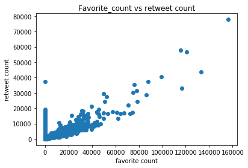

```python
#Lets use the scatterplot
plt.scatter(data=dfa_1,x='favorite_count',y='retweet_count')
plt.title('Favorite_count vs retweet count')
plt.xlabel('favorite count')
plt.ylabel('retweet count');
```

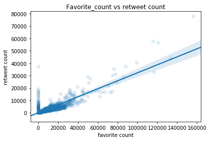

```python
#using regplot with added transparency alpha value ranges from 0(transparent) to 1(opaque)
sns.regplot(data=dfa_1,x='favorite_count',y='retweet_count',scatter_kws={'alpha':1/8})
plt.title('Favorite_count vs retweet count')
plt.xlabel('favorite count')
plt.ylabel('retweet count');
```

```python
#Finding the correlation coefficient
df_tot['favorite_count'].corr(df_tot['retweet_count'])
```

```
0.8619749568866107
```

From above plots and by correlation coefficient we can say that they are **strongly and positively correlated**

## 2)Which is the most popular dog breed?

```python
popular_breeds = df_main.groupby('dog_breed').filter(lambda x: len(x)>= 25)
popular_breeds.dog_breed.value_counts()
```

```
None                        321
Golden retriever            173
Labrador retriever          110
Pembroke                     95
Chihuahua                    93
Pug                          65
Toy poodle                   51
Chow                         51
Samoyed                      45
Pomeranian                   42
Malamute                     34
Cocker spaniel               33
Chesapeake bay retriever     31
French bulldog               30
Miniature pinscher           26
Name: dog_breed, dtype: int64
```

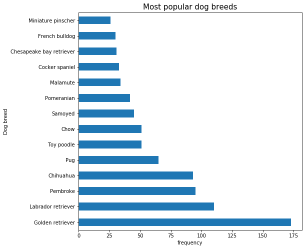

```python
popular_breeds['dog_breed'].value_counts()[1:].plot(kind='barh',figsize=(8,8))
plt.title("Most popular dog breeds",fontsize=15)
plt.ylabel("Dog breed")
plt.xlabel("frequency");
```

Golden retriever is the most popular dog breed

## 3)Which dog breeds have most number of retweets

```python
breeds = df_main[['dog_breed','retweet_count']]
breed_retweet = breeds.groupby('dog_breed').sum()
```

```python
breed_retweet.describe()
```

|  | retweet_count |
| --- | --- |
| count | 114.000000 |
| mean | 46729.026316 |
| std | 103380.679754 |
| min | 394.000000 |
| 25% | 6252.500000 |
| 50% | 16140.500000 |
| 75% | 36473.750000 |
| max | 750368.000000 |

```python
breed_retweet = breed_retweet[breed_retweet.retweet_count > breed_retweet.retweet_count.mean()]
```

```python
breed_retweet = breed_retweet.drop('None')
```

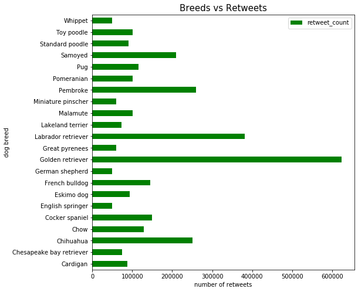

```python
breed_retweet.plot(kind= 'barh',figsize = (8,8), color='g')
plt.xlabel('number of retweets')
plt.ylabel('dog breed')
plt.title('Breeds vs Retweets', fontsize = 15);
```

The most retweeted dog breed is Golden retriever, with Labrador retriever the next most and pembroke later

### 4)What are the most popular dog names

```python
#subsetting the required
dfa_2=df_tot[['name']]
dfa_2.head(3)
```

|  | name |
| --- | --- |
| 0 | Phineas |
| 1 | Tilly |
| 2 | Archie |

```python
dfa_2.name.value_counts()
```

```
None       673
Tucker      10
Penny       10
Charlie     10
Cooper      10
          ...
Bertson      1
Rontu        1
Saydee       1
Tug          1
Tommy        1
Name: name, Length: 911, dtype: int64
```

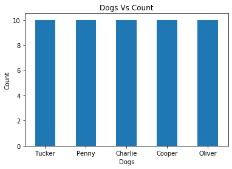

```python
#Extracting the  5 names
base_color=sns.color_palette()[0]
dfa_2.name.value_counts()[1:6].plot(kind='bar',color=base_color)
plt.xticks(rotation=360)
plt.xlabel('Dogs')
plt.ylabel('Count')
plt.title('Dogs Vs Count')
```

**Charlie,Tucker,Cooper,Penny,Oliver** is the popular dog names

### 5)what is the breed of dog belonging to p1 and having most number of favorite_count

```python
#Subsetting the required dataframe
dfa_3=df_tot[['p1','p1_dog','favorite_count']]
dfa_3.head(3)
```

|  | p1 | p1_dog | favorite_count |
| --- | --- | --- | --- |
| 0 | Orange | False | 36240 |
| 1 | Chihuahua | True | 31252 |
| 2 | Chihuahua | True | 23531 |

```python
dfa_3=dfa_3[dfa_3['p1_dog']==True]
dfa_3.p1_dog.value_counts()
```

```
True    1520
Name: p1_dog, dtype: int64
```

```python
dfa_3.head(2)
```

|  | p1 | p1_dog | favorite_count |
| --- | --- | --- | --- |
| 1 | Chihuahua | True | 31252 |
| 2 | Chihuahua | True | 23531 |

```python
list_indices=dfa_3['favorite_count'].sort_values(ascending=False).index.tolist()
dfa_3.favorite_count.sort_values(ascending=False)
```

```
838    156320
320    133141
423    120788
110    116513
873    115476
        ...
67          0
576         0
322         0
318         0
609         0
Name: favorite_count, Length: 1520, dtype: int64
```

```python
k=list_indices[0:10]
k
```

```
[838, 320, 423, 110, 873, 59, 349, 94, 66, 34]
```

```python
dfa_31=dfa_3.loc[k]
dfa_31
```

|  | p1 | p1_dog | favorite_count |
| --- | --- | --- | --- |
| 838 | Labrador retriever | True | 156320 |
| 320 | Lakeland terrier | True | 133141 |
| 423 | Chihuahua | True | 120788 |
| 110 | French bulldog | True | 116513 |
| 873 | Eskimo dog | True | 115476 |
| 59 | English springer | True | 99348 |
| 349 | Standard poodle | True | 88127 |
| 94 | Golden retriever | True | 78662 |
| 66 | Chesapeake bay retriever | True | 74515 |
| 34 | Italian greyhound | True | 72327 |

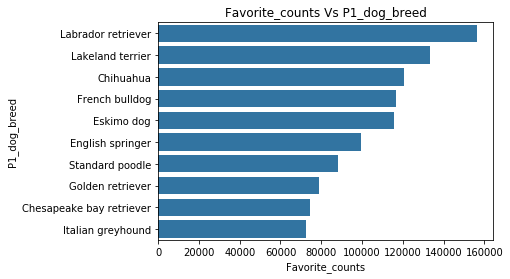

```python
#plotting the barplot
base_color=sns.color_palette()[0]
sns.barplot(data=dfa_31,x='favorite_count',y='p1',color=base_color)
plt.xlabel('Favorite_counts')
plt.ylabel('P1_dog_breed')
plt.title('Favorite_counts Vs P1_dog_breed')
```

**Labrador retriever** is the breed of dog in p1 which has the most favorite_count followed by the rest nine dog_breeds

### 6)what is the breed of dog belonging to p2 and having least number of retweet_count

```python
#Subsetting the required dataframe
dfa_4=df_tot[['p2','p2_dog','retweet_count']]
dfa_4.head(3)
```

|  | p2 | p2_dog | retweet_count |
| --- | --- | --- | --- |
| 0 | Bagel | False | 7715 |
| 1 | Pekinese | True | 5701 |
| 2 | Malamute | True | 3780 |

```python
dfa_4=dfa_4[dfa_4['p2_dog']==True]
dfa_4.p2_dog.value_counts()
```

```
True    1540
Name: p2_dog, dtype: int64
```

```python
dfa_4.head(2)
```

|  | p2 | p2_dog | retweet_count |
| --- | --- | --- | --- |
| 1 | Pekinese | True | 5701 |
| 2 | Malamute | True | 3780 |

```python
list_indices_p2=dfa_4['retweet_count'].sort_values().index.tolist()
dfa_4.retweet_count.sort_values()
```

```
2041       11
2021       18
2029       32
1962       33
2053       39
        ...
346     37441
59      40600
320     43865
423     56768
873     57737
Name: retweet_count, Length: 1540, dtype: int64
```

```python
k1=list_indices_p2[0:10]
k
```

```
[838, 320, 423, 110, 873, 59, 349, 94, 66, 34]
```

```python
dfa_41=dfa_4.loc[k1]
dfa_41
```

|  | p2 | p2_dog | retweet_count |
| --- | --- | --- | --- |
| 2041 | Newfoundland | True | 11 |
| 2021 | Giant schnauzer | True | 18 |
| 2029 | Bloodhound | True | 32 |
| 1962 | Vizsla | True | 33 |
| 2053 | Rottweiler | True | 39 |
| 1810 | West highland white terrier | True | 40 |
| 2055 | Malinois | True | 41 |
| 2044 | Bull mastiff | True | 41 |
| 2056 | Miniature pinscher | True | 42 |
| 2022 | Beagle | True | 42 |

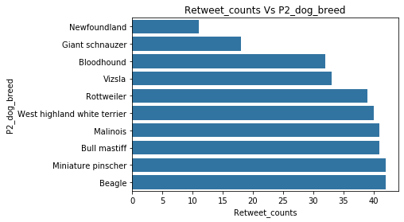

```python
#plotting the barplot
base_color=sns.color_palette()[0]
sns.barplot(data=dfa_41,x='retweet_count',y='p2',color=base_color,errwidth=0)
plt.xlabel('Retweet_counts')
plt.ylabel('P2_dog_breed')
plt.title('Retweet_counts Vs P2_dog_breed')
```

**Newfoundland** is the dog breed of p2 with least retweet count and followed by the rest nine dog_breeds

# Insights

- 1.correlation between favorite_count and retweet_count with a correlation coefficient of 0.86 which means there exits a - -strong positive correlation
- 2.Golden retriever is the most popular dog breed.
- 3.The most retweeted dog breed is Golden retriever, with Labrador retriever the next most and pembroke later
- 4.The most popular dog names are Charlie,Tucker,Cooper,Penny,Oliver with count of 10
- 5.Labrador retriever is the breed of dog in p1 which has the most favorite_count followed by the rest nine dog_breeds
- 6.Newfoundland is the dog breed of p2 with least retweet count and followed by the rest nine dog_breeds